# Indel Signature InsDel3b

# InsDel3b

(corresponds to 83-type signature C_ID3)

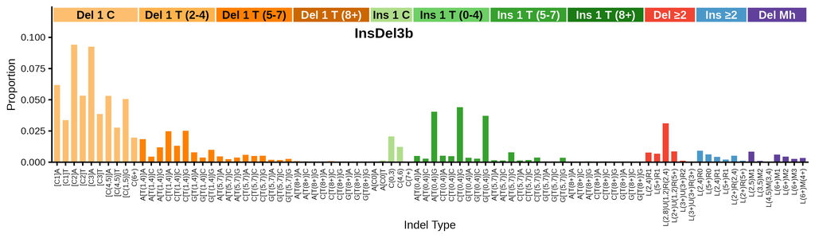

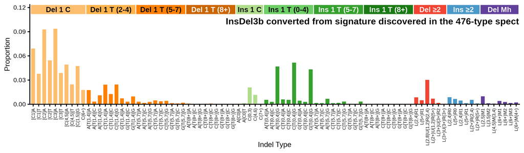

89-type spectrum of the linking tumor CPCT02080086T | cosine similarity to InsDel3b: 0.9952

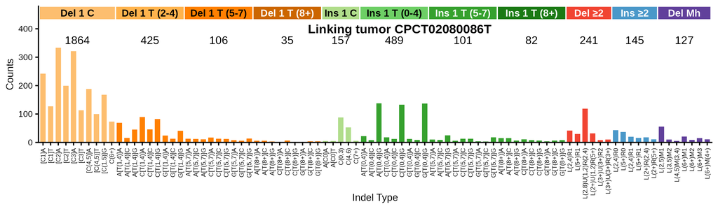

**Click to view decomposition of the linking tumor spectrum**

Partial mutation signature of CPCT02080086T due to InsDel3b

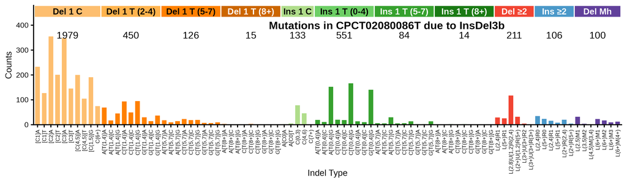

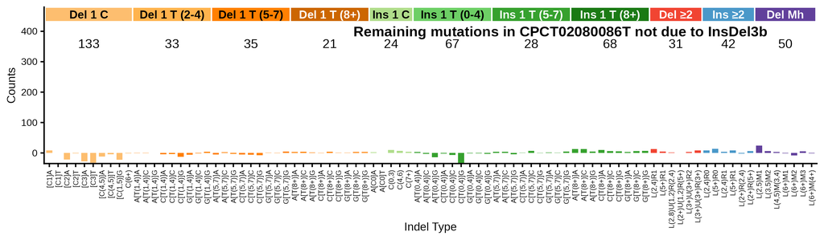

Max neg fraction (maximum allowed negative residual count as fraction of total): 0.07  
N subtract (mutation count assigned to signature): 3768.3  
N residual (mutation count in residual “partial spectrum”): 3.7  
Total negative (sum of negative residual mutation counts): 263.9  
N negative channels (number of channels with negative residual): 39  
P(≥ total negative) (Monte Carlo estimated probability that negative-binomial-sampled spectra from the signature contributing N subtract mutations would produce a total negative count >= the observed Total negative; higher number means not surprising): 0.987

**Per-channel residual breakdown**

| Channel | Spectrum | Sig_Count | Residual | Sig_Prop |
| --- | --- | --- | --- | --- |
| [Del(C):R1]A | 242 | 233.3 | 8.7 | 0.06191 |
| [Del(C):R1]T | 127 | 127.0 | 0 | 0.03371 |
| [Del(C):R2]A | 333 | 354.8 | -21.8 | 0.09415 |
| [Del(C):R2]T | 199 | 200.7 | -1.7 | 0.05325 |
| [Del(C):R3]A | 321 | 348.4 | -27.4 | 0.09245 |
| [Del(C):R3]T | 113 | 145.2 | -32.2 | 0.03854 |
| [Del(C):R(4,5)]A | 188 | 200.1 | -12.1 | 0.05310 |
| [Del(C):R(4,5)]T | 100 | 104.5 | -4.5 | 0.02773 |
| [Del(C):R(1,5)]G | 168 | 190.8 | -22.8 | 0.05063 |
| Del(C):R(6,9) | 73 | 74.3 | -1.3 | 0.01973 |
| A[Del(T):R(1,4)]A | 69 | 69.3 | -0.3 | 0.01839 |
| A[Del(T):R(1,4)]C | 16 | 16.9 | -0.9 | 0.00449 |
| A[Del(T):R(1,4)]G | 45 | 45.0 | 0 | 0.01193 |
| C[Del(T):R(1,4)]A | 89 | 93.7 | -4.7 | 0.02487 |
| C[Del(T):R(1,4)]C | 46 | 49.3 | -3.3 | 0.01309 |
| C[Del(T):R(1,4)]G | 82 | 95.0 | -13 | 0.02520 |
| G[Del(T):R(1,4)]A | 24 | 29.6 | -5.6 | 0.00785 |
| G[Del(T):R(1,4)]C | 13 | 14.3 | -1.3 | 0.00379 |
| G[Del(T):R(1,4)]G | 41 | 37.1 | 3.9 | 0.00985 |
| A[Del(T):R(5,7)]A | 13 | 17.8 | -4.8 | 0.00472 |
| A[Del(T):R(5,7)]C | 12 | 9.5 | 2.5 | 0.00251 |
| A[Del(T):R(5,7)]G | 11 | 14.1 | -3.1 | 0.00373 |
| C[Del(T):R(5,7)]A | 17 | 22.5 | -5.5 | 0.00596 |
| C[Del(T):R(5,7)]C | 13 | 18.9 | -5.9 | 0.00502 |
| C[Del(T):R(5,7)]G | 12 | 19.5 | -7.5 | 0.00517 |
| G[Del(T):R(5,7)]A | 8 | 7.3 | 0.7 | 0.00194 |
| G[Del(T):R(5,7)]C | 6 | 6.4 | -0.4 | 0.00170 |
| G[Del(T):R(5,7)]G | 14 | 9.7 | 4.3 | 0.00257 |
| A[Del(T):R(8,)]A | 6 | 3.2 | 2.8 | 0.00086 |
| A[Del(T):R(8,)]C | 6 | 2.1 | 3.9 | 0.00055 |

[output cut: 59 more lines]

**Click to view similar signatures from Koh et al.**

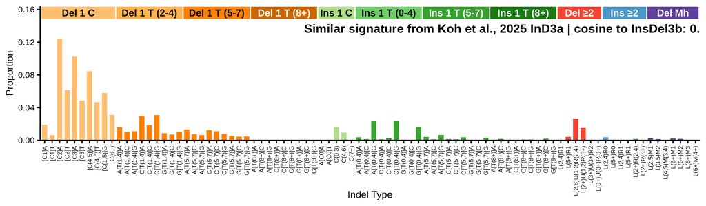

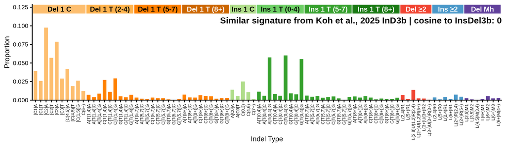

## 476-type representations corresponding to InsDel3b

Extracted 476-type signature corresponding to InsDel3b

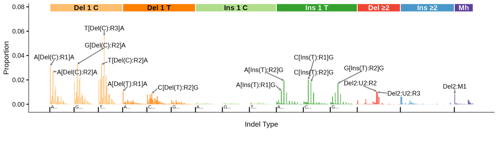

476-type spectrum of the linking tumor CPCT02080086T; cosine similarity to the extracted 476-type signature is 0.9837

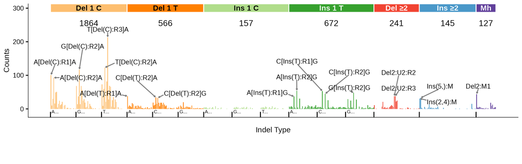

476-type spectrum of best 476-type matching tumor CPCT02020815T; cosine similarity to the extracted 476-type signature is 0.9925

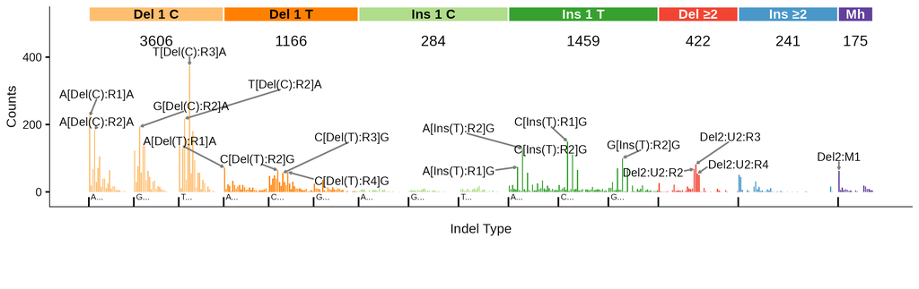

## 83-type signature corresponding to InsDel3b (C_ID3)

**Note**

WARNING: The 83-type signature C_ID3 corresponds to both InsDel3a and InsDel3b. The C_ID3 extraction mainly excluded T deletions in long poly-T contexts that were detected in InsDel3a in extractions in both the 89-type and 476-type classifications, but not in the InsDel3b extractions. Thus, C_ID3 corresponds more closely to InsDel3b than to InsDel3a

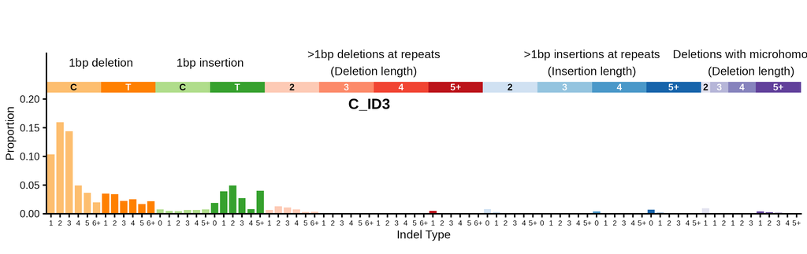

83-type signature converted from signature discovered in the 476-type spectra (using bipartite matching optimization) | cosine similarity to C_ID3: 0.9954

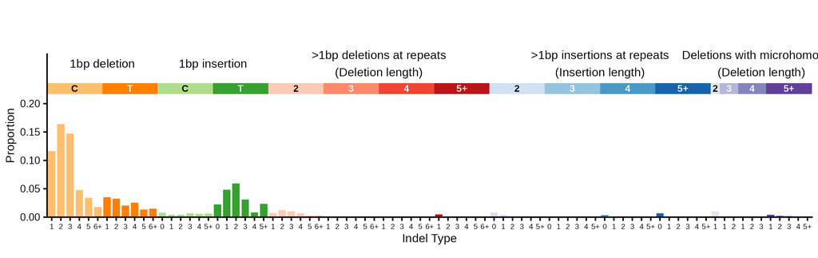

**Click to see flow diagrams: 476-type to 83-type collapse**

These Sankey diagrams show how the 476-type mutation categories are redistributed to 83-type categories using bipartite matching. We only show the diagrams for insertions or deletions of > 1 base because it is for these indels that 476-type categories map to > 1 83-type category.

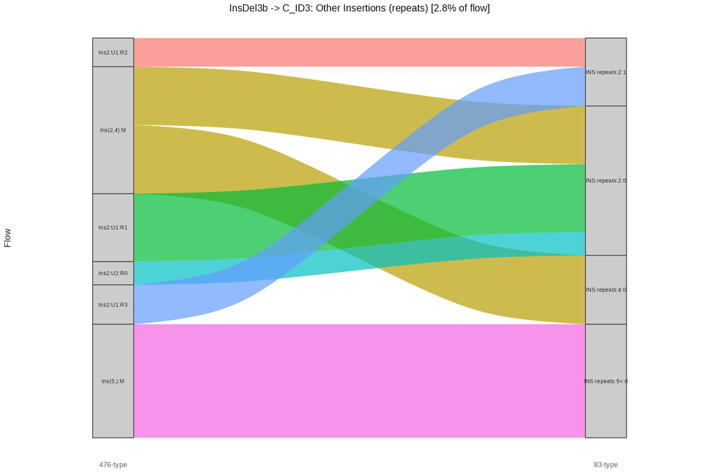

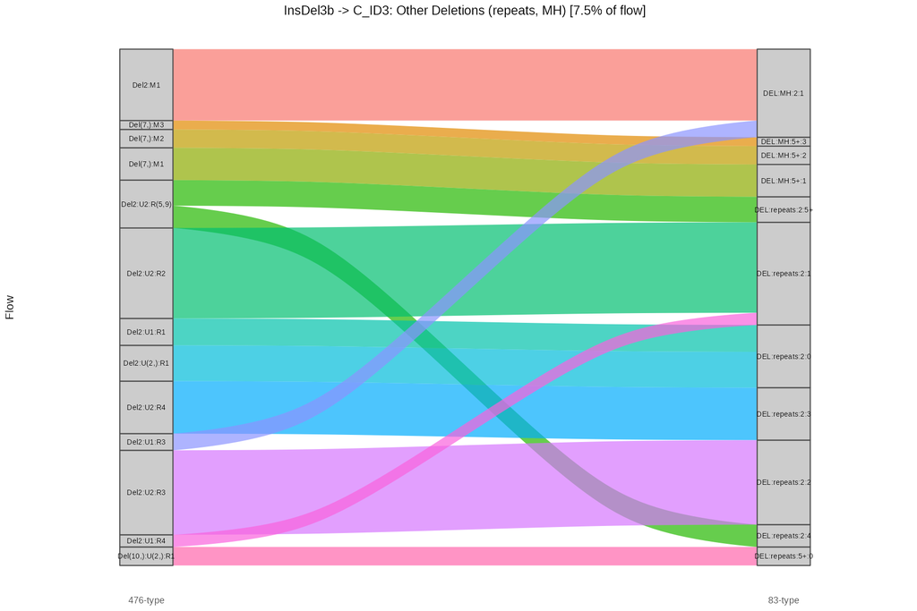

83-type spectrum of the linking tumor CPCT02080086T | cosine similarity to C_ID3: 0.9971

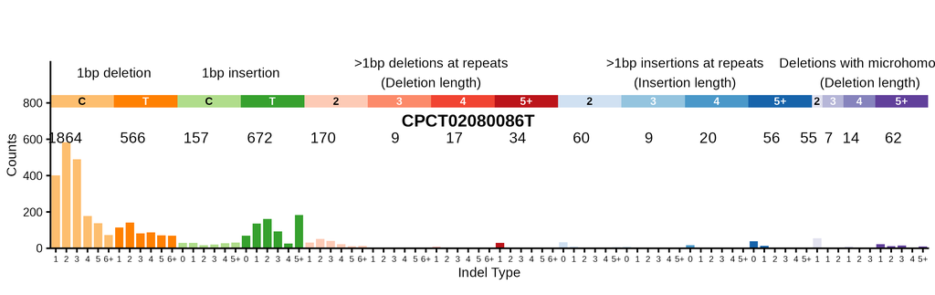

83-type spectrum of best 83-type matching tumor CPCT02020815T | cosine similarity to C_ID3: 0.9973

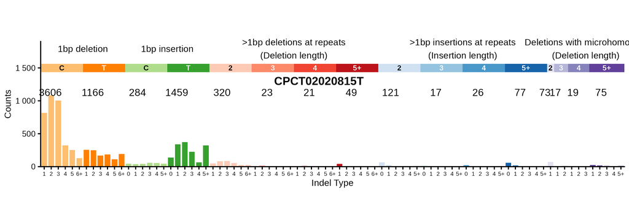

### Similar COSMIC signatures

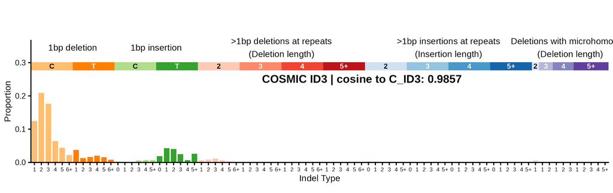

### Similar signatures from Jin et al. 2024

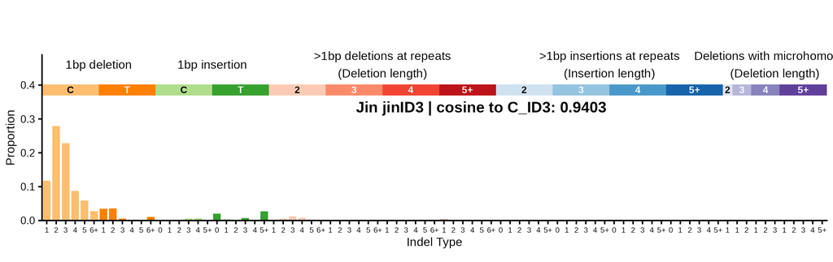